# Data Translation Project

Kalina Gavrilova

2022-05-19

It is no secret that maintaining a healthy lifestyle through a nutritious diet and adequate exercise is difficult for many of us- however, one aspect of the ‘healthy living’ discussion that is often overlooked is the lack of accessibility to healthy foods for lower-income residents in the US. In this report, I will be exploring the relationship between Seattle residents’ geographical location and their frequency of fast food consumption in an attempt to emphasize the inaccessibility of healthy living in the United States which, in combination with a privatized healthcare system, presents yet another obstacle in the way of comfortable living for low-income Americans.

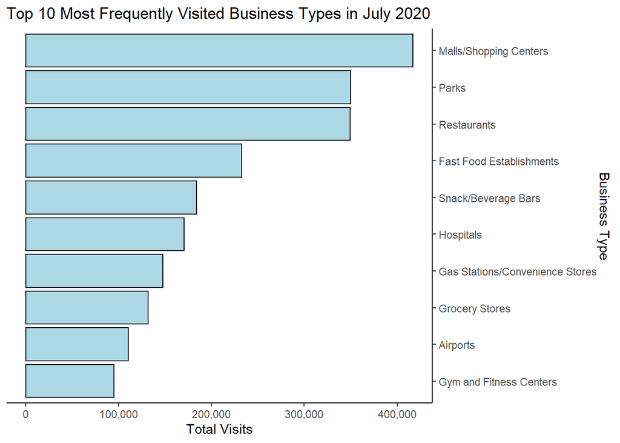

Unsurprisingly, malls and shopping centers were the most frequently visited, which makes sense given that they are made up of many different businesses.

Let’s now consider where visitors of fast food restaurants in the Seattle area come from.

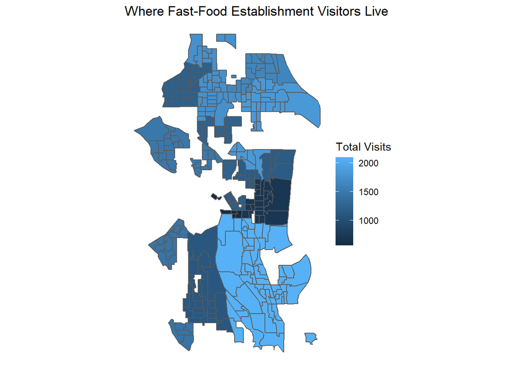

To get a better sense of the habits of residents in these neighborhoods, we can also consider the frequency of which these residents visited gyms and fitness centers in the same period of time.

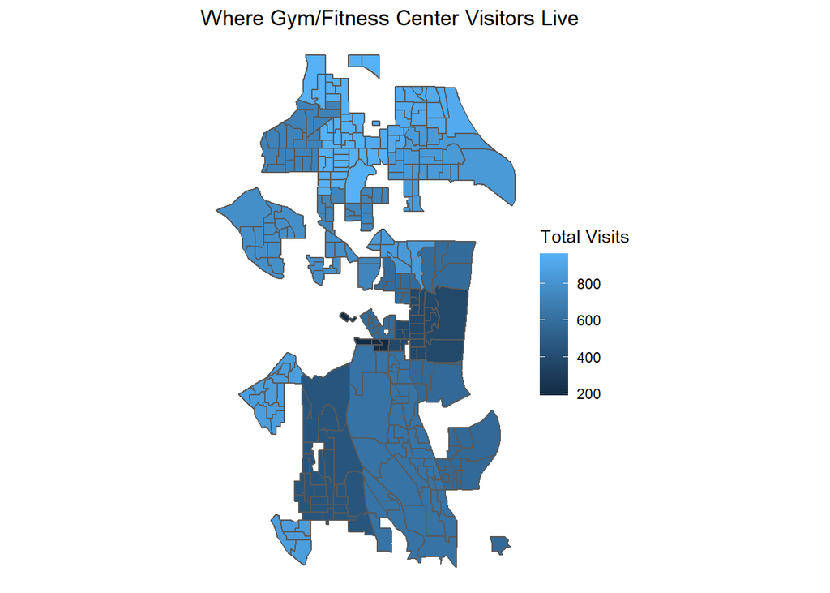

Next, let’s consider the impacts of weekdays and weekends on this issue.

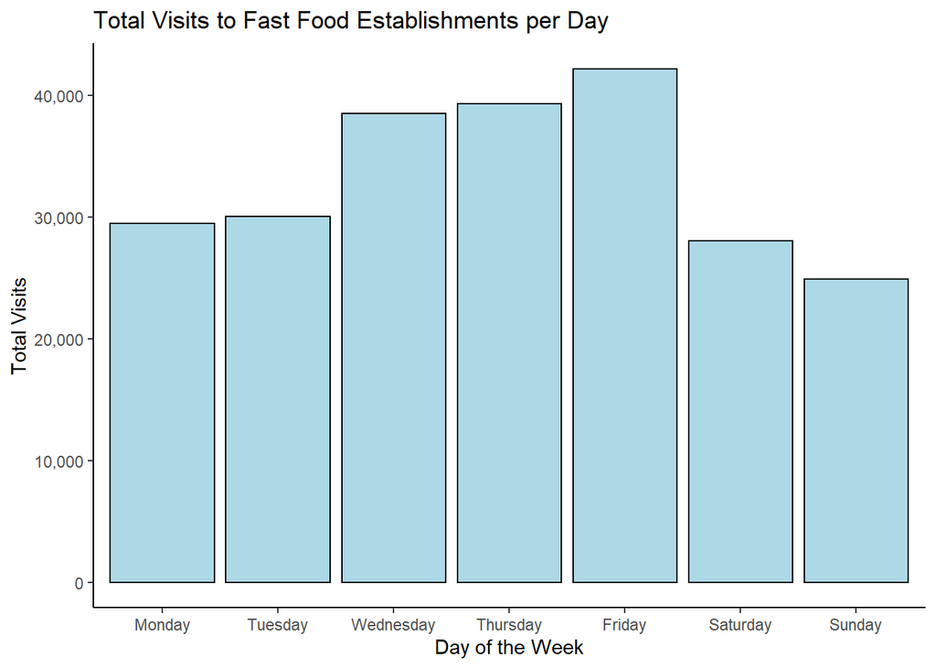

There is a clear pattern in this data- fast food consumption is highest during the week, and falls on weekends. This suggests that fast food consumption is related to people’s availability- presumably, people have more time to cook meals on the weekends. This, however, also demonstrates the inaccessibility of healthy living in the US, as low-income workers are less likely to have control over their work-life balance and might rely on fast food meals more often than higher-income residents.

This pattern, for the most part, remains consistent throughout the entire month.

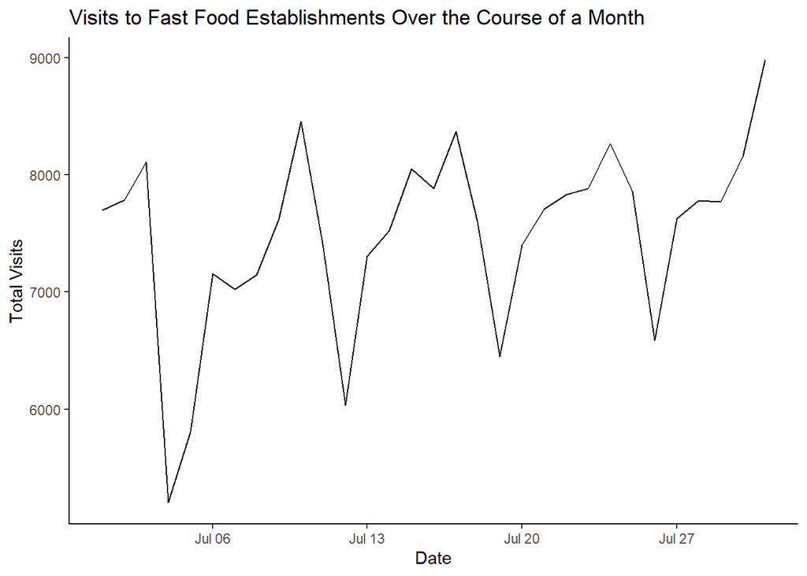

While there are limitations to this data, there is reasonable evidence pointing toward a disparity in the accessibility of healthy habits based on a resident’s geographical location. Whether this is directly due to differences in income level across different neighborhoods, or simply due to disparities within Seattle’s city-planning, it is worth considering these disparities in seeking to address larger societal inequalities.